# VAR Models

2025-08-12

# Introduction to VAR Models

Vector Autoregression (VAR) models are multivariate time series models that capture the linear interdependencies among multiple time series. In a bivariate VAR(p) model, each variable is modeled as a linear function of p lags of both variables.

The general form of a VAR(1) model with two variables is:

$$\begin{bmatrix}
y_{1,t} \\
y_{2,t}
\end{bmatrix} =
\begin{bmatrix}
c_1 \\
c_2
\end{bmatrix} +
\begin{bmatrix}
\phi_{11} & \phi_{12} \\
\phi_{21} & \phi_{22}
\end{bmatrix}
\begin{bmatrix}
y_{1,t-1} \\
y_{2,t-1}
\end{bmatrix} +
\begin{bmatrix}
\varepsilon_{1,t} \\
\varepsilon_{2,t}
\end{bmatrix}$$

# Pattern 1: Positive Cross-Lagged Effects

This pattern shows how variables can reinforce each other over time, creating positive feedback loops.

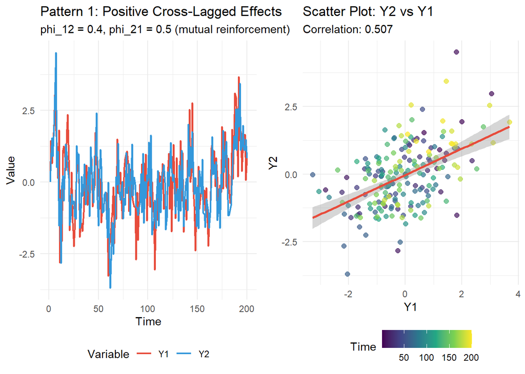

```r
# Set parameters for positive cross-lagged effects
set.seed(42)
T <- 200
phi_matrix_1 <- matrix(c(0.3, 0.4,   # y1 depends on lagged y1 and y2
                         0.5, 0.2), nrow = 2, byrow = TRUE)  # y2 depends on lagged y1 and y2

# Generate VAR(1) process
y <- matrix(0, nrow = T, ncol = 2)
y[1, ] <- c(0, 0)  # Initial values

# Error covariance matrix
sigma <- matrix(c(1, 0.3, 0.3, 1), nrow = 2)

for(t in 2:T) {
  errors <- mvrnorm(1, mu = c(0, 0), Sigma = sigma)
  y[t, ] <- phi_matrix_1 %*% y[t-1, ] + errors
}

# Create data frame
data1 <- data.frame(
  time = 1:T,
  Y1 = y[, 1],
  Y2 = y[, 2]
)

# Time series plot
p1_ts <- ggplot(data1, aes(x = time)) +
  geom_line(aes(y = Y1, color = "Y1"), linewidth = 0.8) +
  geom_line(aes(y = Y2, color = "Y2"), linewidth = 0.8) +
  scale_color_manual(values = c("Y1" = "#e74c3c", "Y2" = "#3498db")) +
  labs(title = "Pattern 1: Positive Cross-Lagged Effects",
       subtitle = "phi_12 = 0.4, phi_21 = 0.5 (mutual reinforcement)",
       x = "Time", y = "Value", color = "Variable") +
  theme_minimal() +
  theme(legend.position = "bottom")

# Scatter plot (Y2 vs Y1)
p1_phase <- ggplot(data1, aes(x = Y1, y = Y2)) +
  geom_point(aes(color = time), size = 2, alpha = 0.7) +
  geom_smooth(method = "lm", se = TRUE, color = "#e74c3c", linewidth = 1) +
  scale_color_viridis_c(name = "Time") +
  labs(title = "Scatter Plot: Y2 vs Y1",
       subtitle = paste("Correlation:", round(cor(data1$Y1, data1$Y2), 3)),
       x = "Y1", y = "Y2") +
  theme_minimal() +
  theme(legend.position = "bottom")

grid.arrange(p1_ts, p1_phase, ncol = 2)
```

```r
# Display coefficient matrix
cat("Coefficient Matrix (Φ):\n")
```

```
## Coefficient Matrix (Φ):
```

```r
print(phi_matrix_1)
```

```
##      [,1] [,2]
## [1,]  0.3  0.4
## [2,]  0.5  0.2
```

# Pattern 2: Negative Cross-Lagged Effects

This pattern demonstrates oscillatory behavior where variables tend to counteract each other.

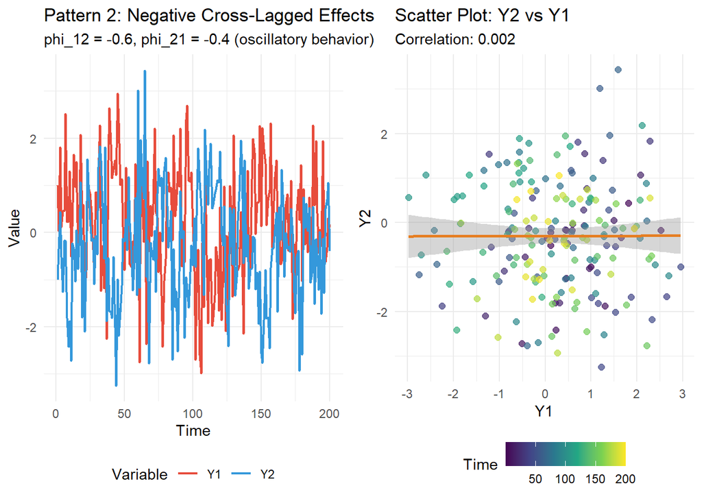

```r
# Set parameters for negative cross-lagged effects
phi_matrix_2 <- matrix(c(0.2, -0.6,   # Y1 negatively affected by lagged Y2
                         -0.4,  0.3), nrow = 2, byrow = TRUE)  # Y2 negatively affected by lagged Y1

# Generate VAR(1) process
y2 <- matrix(0, nrow = T, ncol = 2)
y2[1, ] <- c(1, -1)  # Different initial values

for(t in 2:T) {
  errors <- mvrnorm(1, mu = c(0, 0), Sigma = sigma)
  y2[t, ] <- phi_matrix_2 %*% y2[t-1, ] + errors
}

data2 <- data.frame(
  time = 1:T,
  Y1 = y2[, 1],
  Y2 = y2[, 2]
)

# Time series plot
p2_ts <- ggplot(data2, aes(x = time)) +
  geom_line(aes(y = Y1, color = "Y1"), linewidth = 0.8) +
  geom_line(aes(y = Y2, color = "Y2"), linewidth = 0.8) +
  scale_color_manual(values = c("Y1" = "#e74c3c", "Y2" = "#3498db")) +
  labs(title = "Pattern 2: Negative Cross-Lagged Effects",
       subtitle = "phi_12 = -0.6, phi_21 = -0.4 (oscillatory behavior)",
       x = "Time", y = "Value", color = "Variable") +
  theme_minimal() +
  theme(legend.position = "bottom")

# Scatter plot
p2_phase <- ggplot(data2, aes(x = Y1, y = Y2)) +
  geom_point(aes(color = time), size = 2, alpha = 0.7) +
  geom_smooth(method = "lm", se = TRUE, color = "#e67e22", linewidth = 1) +
  scale_color_viridis_c(name = "Time") +
  labs(title = "Scatter Plot: Y2 vs Y1",
       subtitle = paste("Correlation:", round(cor(data2$Y1, data2$Y2), 3)),
       x = "Y1", y = "Y2") +
  theme_minimal() +
  theme(legend.position = "bottom")

grid.arrange(p2_ts, p2_phase, ncol = 2)
```

```r
cat("Coefficient Matrix (Φ):\n")
```

```
## Coefficient Matrix (Φ):
```

```r
print(phi_matrix_2)
```

```
##      [,1] [,2]
## [1,]  0.2 -0.6
## [2,] -0.4  0.3
```

# Pattern 3: Granger Causality (Y1 → Y2)

This pattern shows unidirectional causality where Y1 influences Y2 but not vice versa.

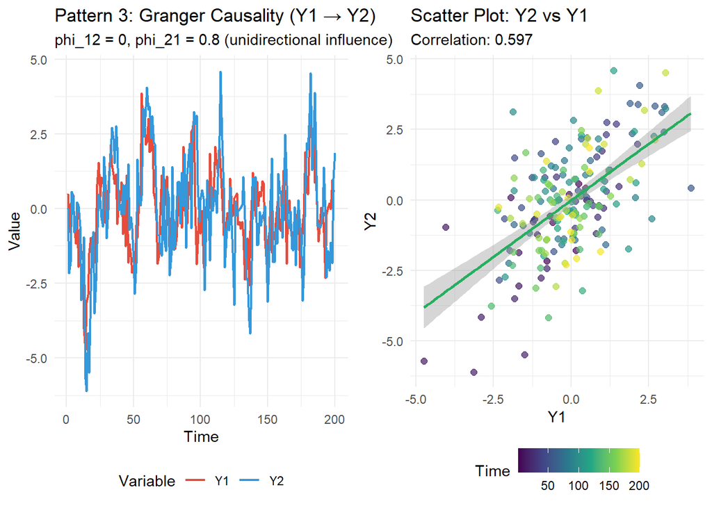

```r
# Granger causality: Y1 causes Y2, but Y2 doesn't cause Y1
phi_matrix_3 <- matrix(c(0.7,  0.0,   # Y1 only depends on its own lag
                         0.8,  0.3), nrow = 2, byrow = TRUE)  # Y2 depends on both lags

y3 <- matrix(0, nrow = T, ncol = 2)
y3[1, ] <- c(0.5, 0)

for(t in 2:T) {
  errors <- mvrnorm(1, mu = c(0, 0), Sigma = sigma)
  y3[t, ] <- phi_matrix_3 %*% y3[t-1, ] + errors
}

data3 <- data.frame(
  time = 1:T,
  Y1 = y3[, 1],
  Y2 = y3[, 2]
)

# Time series plot
p3_ts <- ggplot(data3, aes(x = time)) +
  geom_line(aes(y = Y1, color = "Y1"), linewidth = 0.8) +
  geom_line(aes(y = Y2, color = "Y2"), linewidth = 0.8) +
  scale_color_manual(values = c("Y1" = "#e74c3c", "Y2" = "#3498db")) +
  labs(title = "Pattern 3: Granger Causality (Y1 → Y2)",
       subtitle = "phi_12 = 0, phi_21 = 0.8 (unidirectional influence)",
       x = "Time", y = "Value", color = "Variable") +
  theme_minimal() +
  theme(legend.position = "bottom")

# Phase plot
p3_phase <- ggplot(data3, aes(x = Y1, y = Y2)) +
  geom_point(aes(color = time), size = 2, alpha = 0.7) +
  geom_smooth(method = "lm", se = TRUE, color = "#27ae60", linewidth = 1) +
  scale_color_viridis_c(name = "Time") +
  labs(title = "Scatter Plot: Y2 vs Y1",
       subtitle = paste("Correlation:", round(cor(data3$Y1, data3$Y2), 3)),
       x = "Y1", y = "Y2") +
  theme_minimal() +
  theme(legend.position = "bottom")

grid.arrange(p3_ts, p3_phase, ncol = 2)
```

```r
cat("Coefficient Matrix (Φ):\n")
```

```
## Coefficient Matrix (Φ):
```

```r
print(phi_matrix_3)
```

```
##      [,1] [,2]
## [1,]  0.7  0.0
## [2,]  0.8  0.3
```